# mmse-map

# **TVC-interaction**

### physical activity (TVC) interaction with time equation

```r
eq_tv_intxn <- as.formula("mmse ~ 1 + full_year + age_bl_centered + full_year:age_bl_centered + edu + phys_bp_median  + phys_wp + phys_wp:full_year +
                          (1 + full_year |id)")
```

### full - tvc interaction

```r
model_tv_intx<- lmerTest::lmer(eq_tv_intxn, data=dwn, REML=TRUE) #significant interaction term
lmerTest::summary((model_tv_intx))
```

```
Linear mixed model fit by REML
t-tests use  Satterthwaite approximations to degrees of freedom ['lmerMod']
Formula: mmse ~ 1 + full_year + age_bl_centered + full_year:age_bl_centered +
    edu + phys_bp_median + phys_wp + phys_wp:full_year + (1 +      full_year | id)
   Data: dwn

REML criterion at convergence: 96550.6

Scaled residuals:
    Min      1Q  Median      3Q     Max
-8.6655 -0.3467  0.0666  0.4036  5.7956

Random effects:
 Groups   Name        Variance Std.Dev. Corr
 id       (Intercept) 6.4843   2.5464
          full_year   0.6655   0.8158   0.35
 Residual             4.2871   2.0705
Number of obs: 19805, groups:  id, 2846

Fixed effects:
                            Estimate Std. Error         df t value Pr(>|t|)
(Intercept)                2.591e+01  2.469e-01  2.489e+03 104.952  < 2e-16 ***
full_year                 -5.128e-01  1.937e-02  1.620e+03 -26.477  < 2e-16 ***
age_bl_centered           -8.970e-02  7.159e-03  2.549e+03 -12.530  < 2e-16 ***
edu                        1.497e-01  1.476e-02  2.447e+03  10.146  < 2e-16 ***
phys_bp_median             1.765e-02  2.149e-02  2.557e+03   0.821   0.4115
phys_wp                   -1.789e-02  9.973e-03  1.641e+04  -1.794   0.0729 .
full_year:age_bl_centered -4.020e-02  2.537e-03  1.802e+03 -15.847  < 2e-16 ***
full_year:phys_wp          1.054e-02  1.523e-03  1.558e+04   6.922 4.64e-12 ***
---
Signif. codes:  0 '***' 0.001 '**' 0.01 '*' 0.05 '.' 0.1 ' ' 1

Correlation of Fixed Effects:
            (Intr) fll_yr ag_bl_ edu    phys__ phys_w fl_:__
full_year    0.005
ag_bl_cntrd -0.233 -0.060
edu         -0.972  0.024  0.178
phys_bp_mdn -0.046 -0.018  0.059 -0.005
phys_wp     -0.006  0.037 -0.016 -0.002 -0.008
fll_yr:g_b_ -0.004 -0.163  0.075 -0.010  0.002  0.023
fll_yr:phy_  0.005 -0.010  0.010 -0.001 -0.008 -0.748 -0.012
```

### male - tvc interaction

```r
model_tv_intx<- lmerTest::lmer(eq_tv_intxn, data=dwn_male, REML=TRUE) #significant interaction term
lmerTest::summary((model_tv_intx))
```

```
Linear mixed model fit by REML
t-tests use  Satterthwaite approximations to degrees of freedom ['lmerMod']
Formula: mmse ~ 1 + full_year + age_bl_centered + full_year:age_bl_centered +
    edu + phys_bp_median + phys_wp + phys_wp:full_year + (1 +      full_year | id)
   Data: dwn_male

REML criterion at convergence: 27278.4

Scaled residuals:
    Min      1Q  Median      3Q     Max
-7.5382 -0.3682  0.0618  0.4188  4.1056

Random effects:
 Groups   Name        Variance Std.Dev. Corr
 id       (Intercept) 10.3455  3.2164
          full_year    0.6486  0.8053   0.43
 Residual              4.1620  2.0401
Number of obs: 5570, groups:  id, 802

Fixed effects:
                            Estimate Std. Error         df t value Pr(>|t|)
(Intercept)                2.481e+01  5.213e-01  6.630e+02  47.585  < 2e-16 ***
full_year                 -5.026e-01  3.607e-02  3.920e+02 -13.934  < 2e-16 ***
age_bl_centered           -1.431e-01  1.665e-02  7.290e+02  -8.594  < 2e-16 ***
edu                        1.714e-01  2.945e-02  6.470e+02   5.819 9.30e-09 ***
phys_bp_median             7.601e-02  4.338e-02  6.640e+02   1.752 0.080225 .
phys_wp                   -2.341e-02  1.697e-02  4.580e+03  -1.380 0.167736
full_year:age_bl_centered -3.743e-02  4.956e-03  4.400e+02  -7.551 2.51e-13 ***
full_year:phys_wp          8.832e-03  2.412e-03  4.310e+03   3.661 0.000254 ***
---
Signif. codes:  0 '***' 0.001 '**' 0.01 '*' 0.05 '.' 0.1 ' ' 1

Correlation of Fixed Effects:
            (Intr) fll_yr ag_bl_ edu    phys__ phys_w fl_:__
full_year    0.033
ag_bl_cntrd -0.227 -0.094
edu         -0.966  0.022  0.167
phys_bp_mdn -0.094 -0.008  0.068  0.019
phys_wp     -0.003  0.052 -0.015 -0.007  0.007
fll_yr:g_b_ -0.026 -0.108  0.174  0.003  0.003  0.039
fll_yr:phy_  0.000 -0.018  0.012  0.006 -0.016 -0.746 -0.024
```

### female - tvc interaction

```r
model_tv_intx<- lmerTest::lmer(eq_tv_intxn, data=dwn_female, REML=TRUE) #significant interaction term, but loose within person effects
lmerTest::summary((model_tv_intx))
```

```
Linear mixed model fit by REML
t-tests use  Satterthwaite approximations to degrees of freedom ['lmerMod']
Formula: mmse ~ 1 + full_year + age_bl_centered + full_year:age_bl_centered +
    edu + phys_bp_median + phys_wp + phys_wp:full_year + (1 +      full_year | id)
   Data: dwn_female

REML criterion at convergence: 69090.7

Scaled residuals:
    Min      1Q  Median      3Q     Max
-8.6427 -0.3416  0.0697  0.4011  5.7776

Random effects:
 Groups   Name        Variance Std.Dev. Corr
 id       (Intercept) 4.5679   2.1373
          full_year   0.6744   0.8212   0.32
 Residual             4.3387   2.0830
Number of obs: 14235, groups:  id, 2044

Fixed effects:
                            Estimate Std. Error         df t value Pr(>|t|)
(Intercept)                2.593e+01  2.696e-01  1.821e+03  96.177  < 2e-16 ***
full_year                 -5.156e-01  2.298e-02  1.226e+03 -22.435  < 2e-16 ***
age_bl_centered           -6.834e-02  7.383e-03  1.822e+03  -9.257  < 2e-16 ***
edu                        1.661e-01  1.647e-02  1.785e+03  10.084  < 2e-16 ***
phys_bp_median             4.693e-03  2.363e-02  1.896e+03   0.199    0.843
phys_wp                   -1.479e-02  1.231e-02  1.190e+04  -1.201    0.230
full_year:age_bl_centered -4.085e-02  2.958e-03  1.360e+03 -13.809  < 2e-16 ***
full_year:phys_wp          1.165e-02  1.958e-03  1.132e+04   5.950 2.77e-09 ***
---
Signif. codes:  0 '***' 0.001 '**' 0.01 '*' 0.05 '.' 0.1 ' ' 1

Correlation of Fixed Effects:
            (Intr) fll_yr ag_bl_ edu    phys__ phys_w fl_:__
full_year   -0.011
ag_bl_cntrd -0.238 -0.044
edu         -0.975  0.027  0.187
phys_bp_mdn -0.039 -0.022  0.056 -0.001
phys_wp     -0.012  0.032 -0.016  0.005 -0.017
fll_yr:g_b_  0.002 -0.183  0.024 -0.013  0.004  0.017
fll_yr:phy_  0.011 -0.007  0.009 -0.008 -0.003 -0.751 -0.008
```

## **wp person PA X years in study** is sig. across all 3 analyses. The graph below helps to explain this interaction.

## Overtime, the effects of PA are more pronounced. specifically, exercising becomes increasingly important with age. With increasing age, if you walk more than your own average, you are expected to have higher mmse scores at that occasion.

# hypothetical graph

```
      Min.    1st Qu.     Median       Mean    3rd Qu.       Max.
-18.170000  -1.104000  -0.230000   0.001103   0.776100  31.200000
```

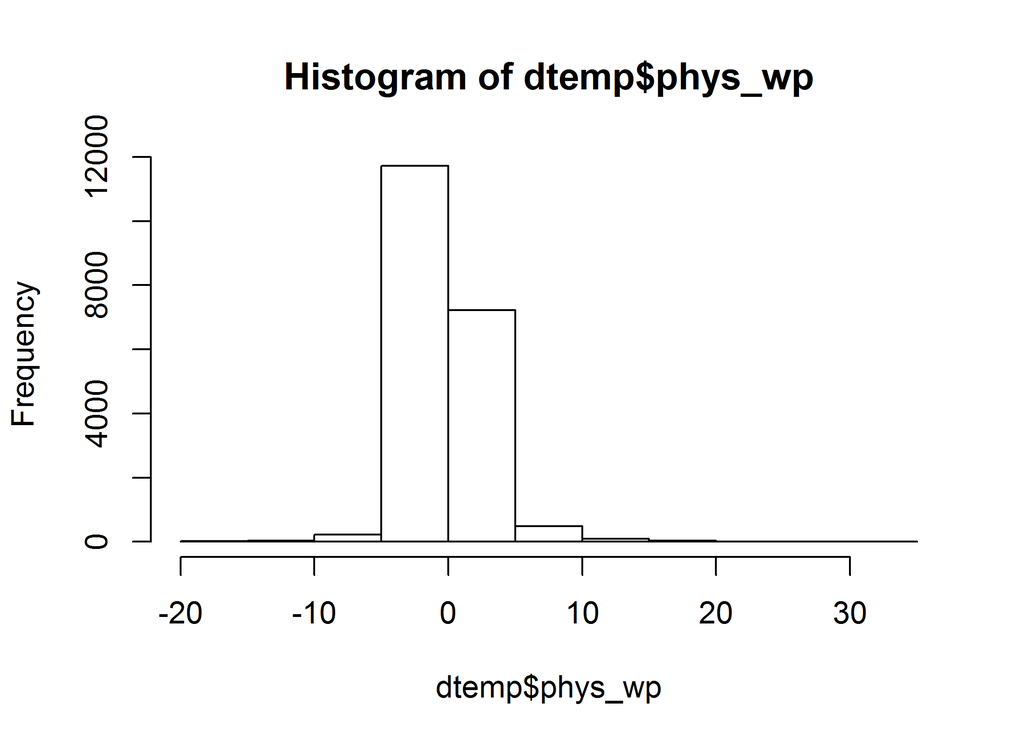

```
Source: local data frame [9 x 3]
Groups: id [1]

        id    phys_wp phys_wp_dichot
     <int>      <dbl>          <chr>
1 43596435  1.5148148           HIGH
2 43596435 -1.4018519            LOW
3 43596435  1.4648148           HIGH
4 43596435 -1.1518519            LOW
5 43596435 -2.9018519            LOW
6 43596435 -0.3185185            mid
7 43596435  6.1814815           HIGH
8 43596435 -1.9851852            LOW
9 43596435 -1.4018519            LOW
```

```
Classes 'tbl_df', 'tbl' and 'data.frame':   1046 obs. of  15 variables:
 $ id                   : int  4127190 4127190 4127190 4127190 4127190 4127190 4127190 4127190 4127190 6608444 ...
 $ full_year            : int  0 1 2 3 4 5 6 7 8 0 ...
 $ age_bl               : num  79.7 79.7 79.7 79.7 79.7 ...
 $ age_at_visit_centered: num  -0.7 0.343 1.52 2.333 3.343 ...
 $ physical_activity    : num  1 0.667 1.25 2.25 0 ...
 $ phys_bl_bp           : num  -2.08 -2.08 -2.08 -2.08 -2.08 ...
 $ phys_bp_mean         : num  -1.95 -1.95 -1.95 -1.95 -1.95 ...
 $ phys_bp_median       : num  -1.08 -1.08 -1.08 -1.08 -1.08 ...
 $ phys_wp              : num  0.32407 -0.00926 0.57407 1.57407 -0.67593 ...
 $ mmse                 : num  26 30 30 28 28 30 26 27 29 30 ...
 $ age_bl_centered      : num  3.86 3.86 3.86 3.86 3.86 ...
 $ female               : logi  TRUE TRUE TRUE TRUE TRUE TRUE ...
 $ edu                  : int  20 20 20 20 20 20 20 20 20 20 ...
 $ pred                 : num  28.8 28.6 28.5 28.4 28.2 ...
 $ phys_wp_dichot       : chr  "mid" "mid" "mid" "HIGH" ...
 - attr(*, "na.action")=Class 'omit'  Named int [1:552] 8 21 22 23 293 294 295 296 297 298 ...
  .. ..- attr(*, "names")= chr [1:552] "8" "21" "22" "23" ...
```

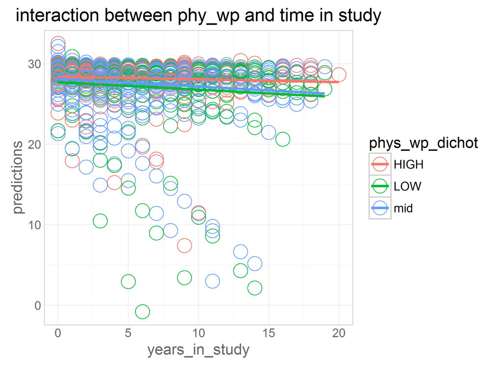

# **TVC by age-at-visit interaction**

```r
eq_tv_intxn <- as.formula("mmse ~ 1 + full_year + age_bl_centered + full_year:age_bl_centered + age_at_visit_centered + edu + phys_bp_median  + phys_wp + phys_wp:age_at_visit_centered +
                          (1 + full_year |id)")
```

```r
model_tv_intx<- lmerTest::lmer(eq_tv_intxn, data=dwn, REML=TRUE) #significant interaction term
lmerTest::summary((model_tv_intx))
```

```
Linear mixed model fit by REML
t-tests use  Satterthwaite approximations to degrees of freedom ['lmerMod']
Formula: mmse ~ 1 + full_year + age_bl_centered + full_year:age_bl_centered +
    age_at_visit_centered + edu + phys_bp_median + phys_wp +      phys_wp:age_at_visit_centered + (1 + full_year | id)
   Data: dwn

REML criterion at convergence: 96523.7

Scaled residuals:
    Min      1Q  Median      3Q     Max
-8.5182 -0.3498  0.0671  0.4052  5.7897

Random effects:
 Groups   Name        Variance Std.Dev. Corr
 id       (Intercept) 6.480    2.5456
          full_year   0.664    0.8149   0.34
 Residual             4.281    2.0690
Number of obs: 19805, groups:  id, 2846

Fixed effects:
                                Estimate Std. Error         df t value Pr(>|t|)
(Intercept)                    2.080e+01  7.864e-01  1.957e+04  26.449  < 2e-16 ***
full_year                      6.196e-01  1.665e-01  1.861e+04   3.721 0.000199 ***
age_bl_centered                1.029e+00  1.643e-01  1.859e+04   6.263 3.85e-10 ***
age_at_visit_centered         -1.121e+00  1.642e-01  1.854e+04  -6.826 9.00e-12 ***
edu                            1.482e-01  1.476e-02  2.451e+03  10.041  < 2e-16 ***
phys_bp_median                 1.767e-02  2.148e-02  2.559e+03   0.822 0.410881
phys_wp                        3.466e-02  6.621e-03  1.622e+04   5.236 1.66e-07 ***
full_year:age_bl_centered     -4.041e-02  2.542e-03  1.817e+03 -15.898  < 2e-16 ***
age_at_visit_centered:phys_wp  4.953e-03  8.889e-04  1.631e+04   5.572 2.55e-08 ***
---
Signif. codes:  0 '***' 0.001 '**' 0.01 '*' 0.05 '.' 0.1 ' ' 1

Correlation of Fixed Effects:
            (Intr) fll_yr ag_bl_ ag_t__ edu    phys__ phys_w fl_:__
full_year   -0.943
ag_bl_cntrd -0.952  0.992
ag_t_vst_cn  0.949 -0.993 -0.999
edu         -0.285 -0.018 -0.014  0.021
phys_bp_mdn -0.013 -0.004  0.001  0.002 -0.005
phys_wp      0.019 -0.016 -0.022  0.022 -0.003 -0.021
fll_yr:g_b_  0.058 -0.080 -0.059  0.062 -0.009  0.002  0.025
ag_t_vst_:_  0.000  0.000 -0.003  0.002  0.006 -0.008  0.051  0.046
```

```r
dtemp$pred<- predict(model_tv_intx)
```

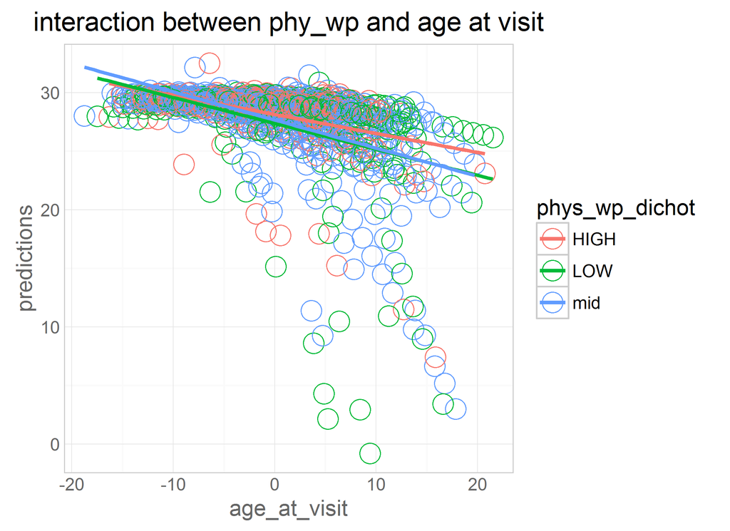

# **Fluctuation in MMSE**

## Here, I explore the effects of using deviations from your average mmse score, to see if within person changes in PA also predict mmse changes at that occasion

## ? mostly this was exploratory and I wanted to know if you think it makes sense ??